# Efetividade da certificação

Francisco d’Albertas

27/10/2021

Após parear propriedades controle, já dá pra testar se o pareamento foi bom; se há alguma tendência.

Para cada propriedade certificada, eu calculei a diferença de tempo entre a certificação e os anos do período analisado (2004-1017). Esses valores podem ser negativos – anos anteriores a certificação – ou positivos – anos posteriores a certificação. No ano da certificação, o valor é zero. No caso das propriedades certificadas, atribui um valor zero para todas.

### Desmatamento

A taxa de desmatamento foi calculada sobre a área de vegetação nativa de cada propriedade

**Regressão em painel para Mata Atlântica:**

```r
m02 <- plm(formula = def_rate_1 ~ treatment*event_time, data = dfma,
           effect="individual",model = "within", index = c("COD_IMOVEL","year"))


summary(m02)
```

```
## Oneway (individual) effect Within Model
##
## Call:
## plm(formula = def_rate_1 ~ treatment * event_time, data = dfma,
##     effect = "individual", model = "within", index = c("COD_IMOVEL",
##         "year"))
##
## Balanced Panel: n = 781, T = 13, N = 10153
##
## Residuals:
##       Min.    1st Qu.     Median    3rd Qu.       Max.
## -0.1147039 -0.0035256  0.0000000  0.0000000  0.9230769
##
## Coefficients:
##                  Estimate  Std. Error t-value Pr(>|t|)
## event_time-13  0.00193424  0.00934921  0.2069   0.8361
## event_time-12  0.00557443  0.00930417  0.5991   0.5491
## event_time-11  0.00086721  0.00899778  0.0964   0.9232
## event_time-10  0.01134576  0.00896515  1.2655   0.2057
## event_time-9   0.00381251  0.00871497  0.4375   0.6618
## event_time-8   0.00625001  0.00779008  0.8023   0.4224
## event_time-7   0.00756643  0.00779008  0.9713   0.3314
## event_time-6   0.00105061  0.00779008  0.1349   0.8927
## event_time-5   0.00528652  0.00774923  0.6822   0.4951
## event_time-4   0.00539585  0.00774923  0.6963   0.4863
## event_time-3   0.00354962  0.00774923  0.4581   0.6469
## event_time-2   0.00901247  0.00774923  1.1630   0.2449
## event_time-1   0.00227059  0.00828384  0.2741   0.7840
## event_time0    0.00784237  0.00828384  0.9467   0.3438
## event_time1    0.00645033  0.00829510  0.7776   0.4368
## event_time2    0.00443300  0.00838703  0.5286   0.5971
## event_time3    0.00685084  0.00839881  0.8157   0.4147
## event_time4    0.00547876  0.00850862  0.6439   0.5197
## event_time5   -0.00072318  0.01603240 -0.0451   0.9640
## event_time6    0.00057644  0.01603240  0.0360   0.9713
## event_time7    0.00305838  0.01603240  0.1908   0.8487
##
## Total Sum of Squares:    19.222
## Residual Sum of Squares: 19.208
## R-Squared:      0.00075909
## Adj. R-Squared: -0.084835
## F-statistic: 0.338267 on 21 and 9351 DF, p-value: 0.99792
```

O coeficiente da interação não esta sendo estimado, nao sei porque.

**Regressão em painel para Cerrado:**

```r
m03 <- plm(formula = def_rate_1 ~ treatment*event_time, data = dfce,
           effect="individual",model = "within", index = c("COD_IMOVEL","year"))


summary(m03)
```

```
## Oneway (individual) effect Within Model
##
## Call:
## plm(formula = def_rate_1 ~ treatment * event_time, data = dfce,
##     effect = "individual", model = "within", index = c("COD_IMOVEL",
##         "year"))
##
## Balanced Panel: n = 1728, T = 14, N = 24192
##
## Residuals:
##       Min.    1st Qu.     Median    3rd Qu.       Max.
## -0.1523810 -0.0090756  0.0000000  0.0000000  0.9285714
##
## Coefficients:
##                  Estimate  Std. Error t-value Pr(>|t|)
## event_time-13 -0.00084735  0.03708550 -0.0228   0.9818
## event_time-12  0.00248912  0.03708550  0.0671   0.9465
## event_time-11  0.00766646  0.03708550  0.2067   0.8362
## event_time-10  0.01423556  0.03276896  0.4344   0.6640
## event_time-9   0.02066617  0.03269903  0.6320   0.5274
## event_time-8   0.00374051  0.03261074  0.1147   0.9087
## event_time-7   0.01732504  0.03233615  0.5358   0.5921
## event_time-6   0.01517049  0.03233615  0.4691   0.6390
## event_time-5   0.00419305  0.03231614  0.1298   0.8968
## event_time-4   0.00469760  0.03231614  0.1454   0.8844
## event_time-3   0.00707836  0.03231614  0.2190   0.8266
## event_time-2   0.00574401  0.03231614  0.1777   0.8589
## event_time-1   0.01768771  0.03231614  0.5473   0.5842
## event_time0    0.01524066  0.03234635  0.4712   0.6375
## event_time1    0.01142586  0.03235415  0.3531   0.7240
## event_time2    0.01130797  0.03235415  0.3495   0.7267
## event_time3    0.01375544  0.03235415  0.4252   0.6707
## event_time4    0.02062151  0.03240919  0.6363   0.5246
## event_time5    0.01306850  0.03241949  0.4031   0.6869
## event_time6    0.02843931  0.03243840  0.8767   0.3806
## event_time7    0.00583984  0.03347171  0.1745   0.8615
## event_time8    0.00861928  0.03347171  0.2575   0.7968
##
## Total Sum of Squares:    85.644
## Residual Sum of Squares: 85.447
## R-Squared:      0.0022998
## Adj. R-Squared: -0.075455
## F-statistic: 2.3514 on 22 and 22442 DF, p-value: 0.00034447
```

** Segui o mesmo padrão para as outras variáveis dependentes: taxa de regeneração (calculada como a razão entre a área regenerada e a área da propriedade) e a razão de vegetação nativa (área de vegetação nativa/[area equivalente a 20% da propriedade)

### Representação gráfica dos resultados

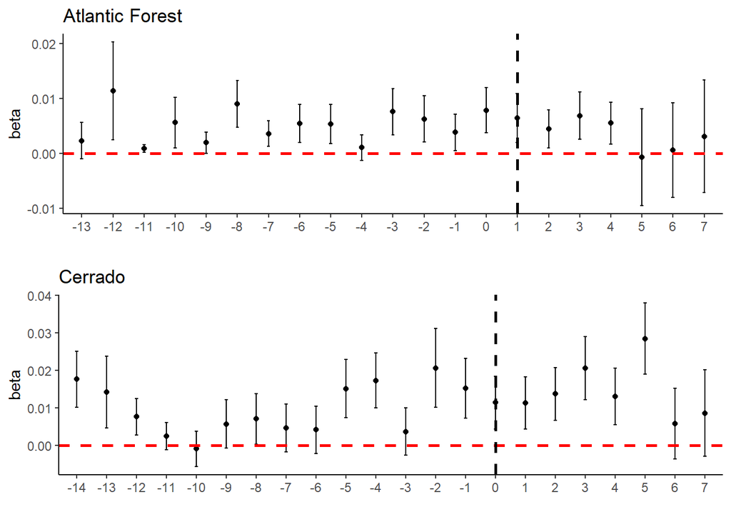

Figura1. Taxa de desmatamento

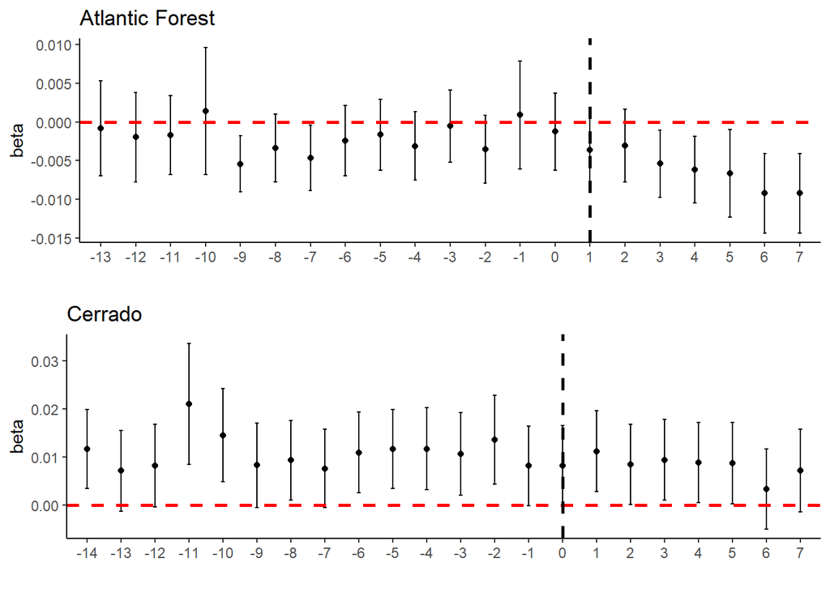

Figura2. Taxa de regeneração

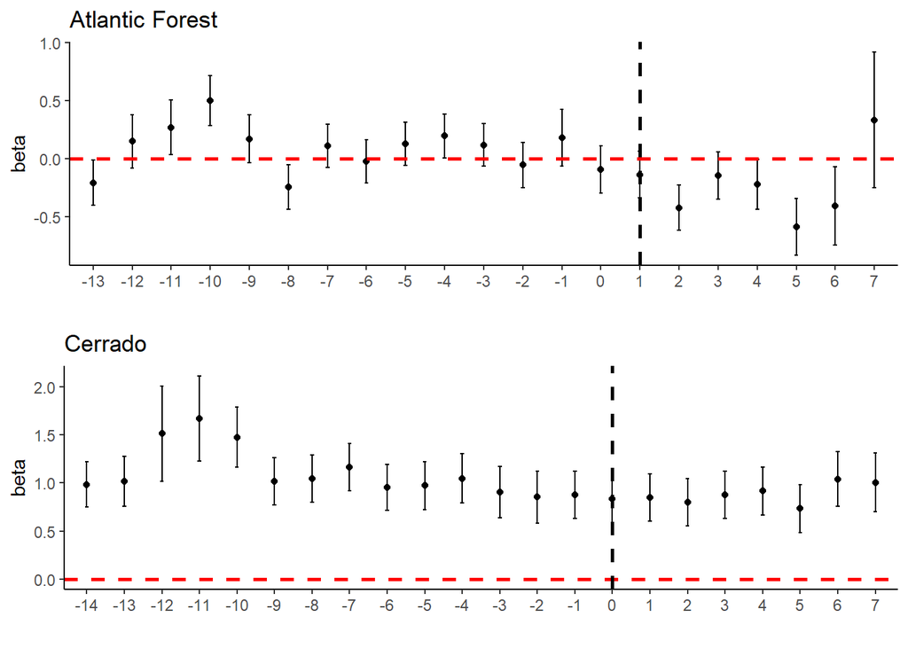

Figura 3. Razão de cobertura de vegetação

### Observações

Além da discussão sobre se os modelos estão corretos, parece que o pareamento não foi muito efetivo. Isso porque se os gráficos estão corretos e indicam a diferença entre as propriedades certificadas e não certificadas, as barras de erro à esquerda da linha vertical pontilhada deveriam estar mais perto do zero, cruzando o zero de preferência.

Pro cerrado esse efeito parece ainda pior.